# Human Activity Recognition - Weight Lifting Exploratory Data Analysis

Maurício Collaça

December, 5th 2017

Six young health participants were asked to perform one set of 10 repetitions of the Unilateral Dumbbell Biceps Curl in five different fashions: exactly according to the specification (Class A), throwing the elbows to the front (Class B), lifting the dumbbell only halfway (Class C), lowering the dumbbell only halfway (Class D) and throwing the hips to the front (Class E).

Read more: http://groupware.les.inf.puc-rio.br/har#weight_lifting_exercises

## Data validation and transformation

The training set row and columns dimensions

```
## [1] 19622   160
```

The testing set row and columns dimensions

```
## [1]  20 160
```

### Missing values: NA, “#DIV/0!” or “”

100 training variables have either 98% or 100% missing values.

```
trainNAproportion
   0 0.98    1
  60   94    6
```

100 testing variables have 100% missing values.

```
testNAproportion
  0   1
 60 100
```

By visually inspecting the dataset it was concluded the high missing value proportion is due to statistics calculated in time windows and only stored at rows whose new_window = “yes”, characterizing a messy data set where rows are not allways representing a single observation. As those statistics can be recalculated from the respective raw data when and if necessary, they will be ignored.

## Exploratory Data Analysis

### Contingency table

Sensor readings by classification and user

```r
with(training, rbind(cbind(table(classe, user_name), "(total)" = table(classe)),
                     "(total)" = c(table(user_name), length(user_name))))
```

```
                   adelmo carlitos charles eurico jeremy pedro (total)
A:correctly          1165      834     899    865   1177   640    5580
B:throwing elbows     776      690     745    592    489   505    3797
C:lifting halfway     750      493     539    489    652   499    3422
D:lowering halfway    515      486     642    582    522   469    3216
E:throwing hips       686      609     711    542    562   497    3607
(total)              3892     3112    3536   3070   3402  2610   19622
```

### Heatmaps

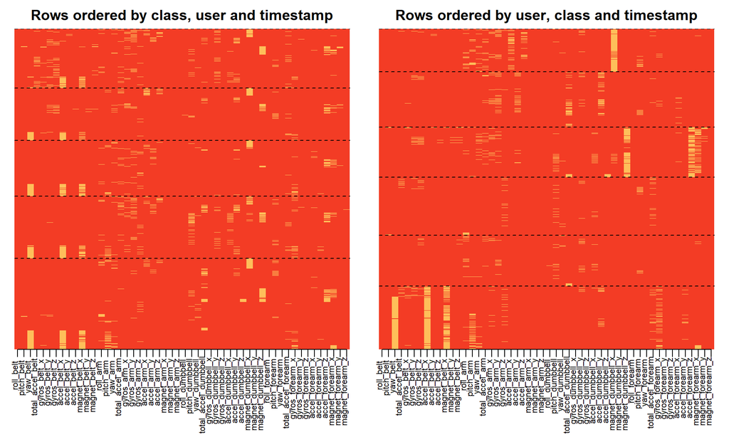

Heatmap ordered by hierarchical cluster dendrograms of the Euclidean distances and complete-linkage agglomeration method.

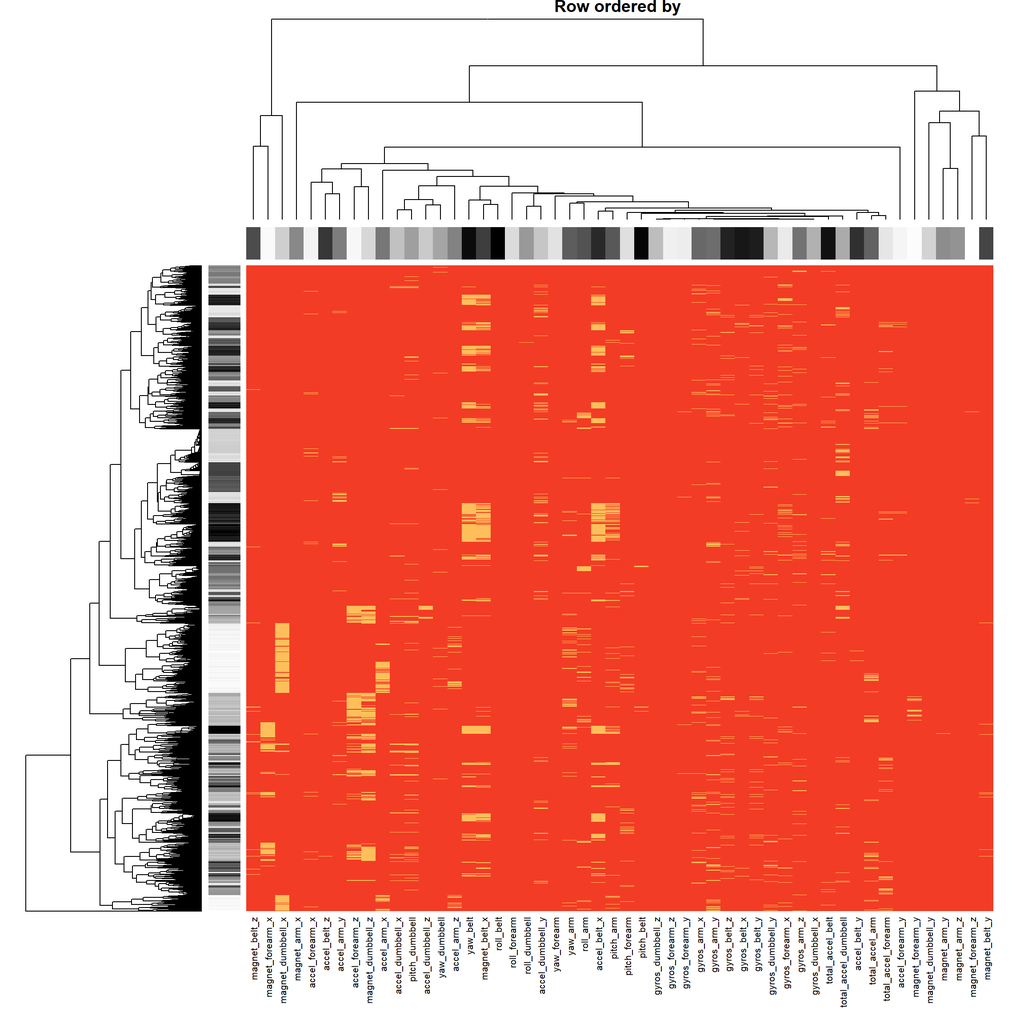

Heatmaps segmented by sensor set, ordered by hierarchical cluster of Euclidean distances and complete-linkage agglomeration method.

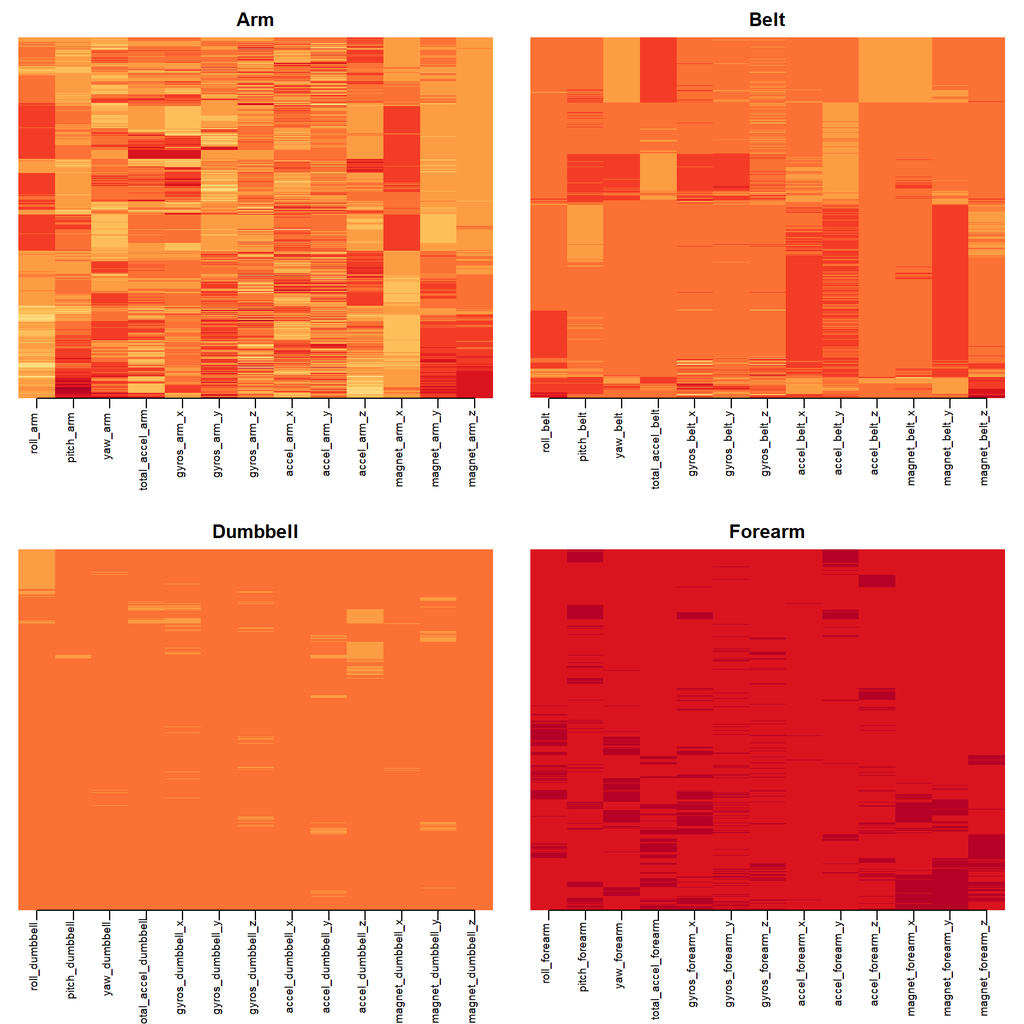

### Generalized pairs plots

##### Accelerometer totals by sensor set

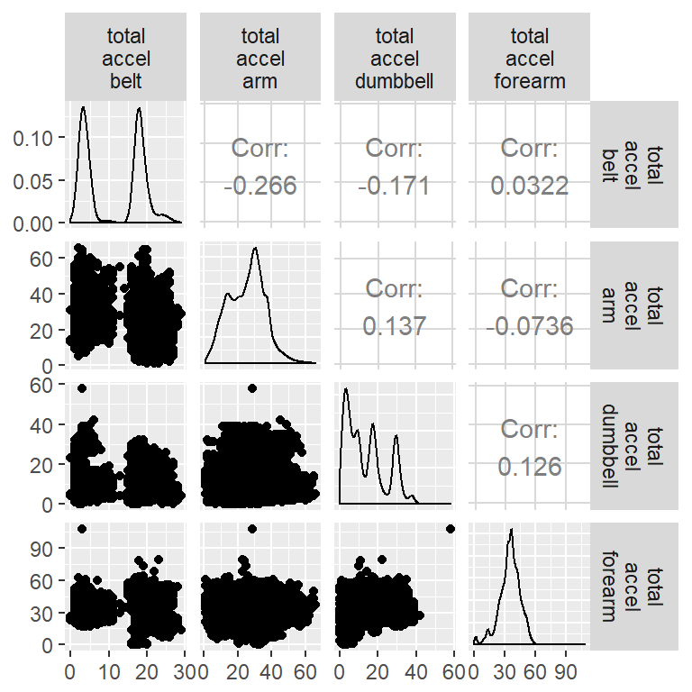

#### Euler angles (pitch, roll and yaw) from sensors (belt, arm, dumbell and Forearm)

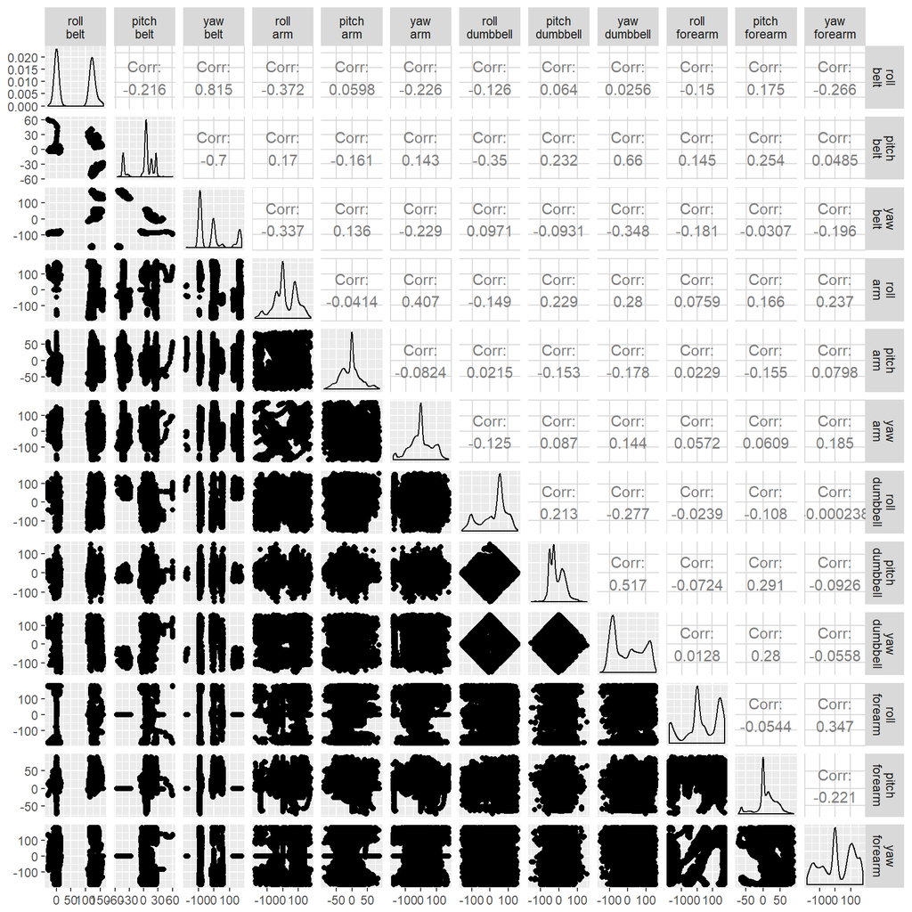

#### Arm sensor set

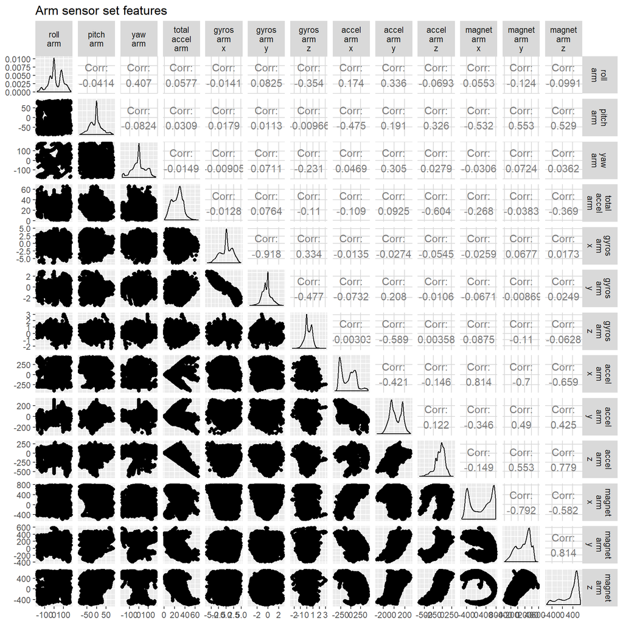

#### Belt sensor set

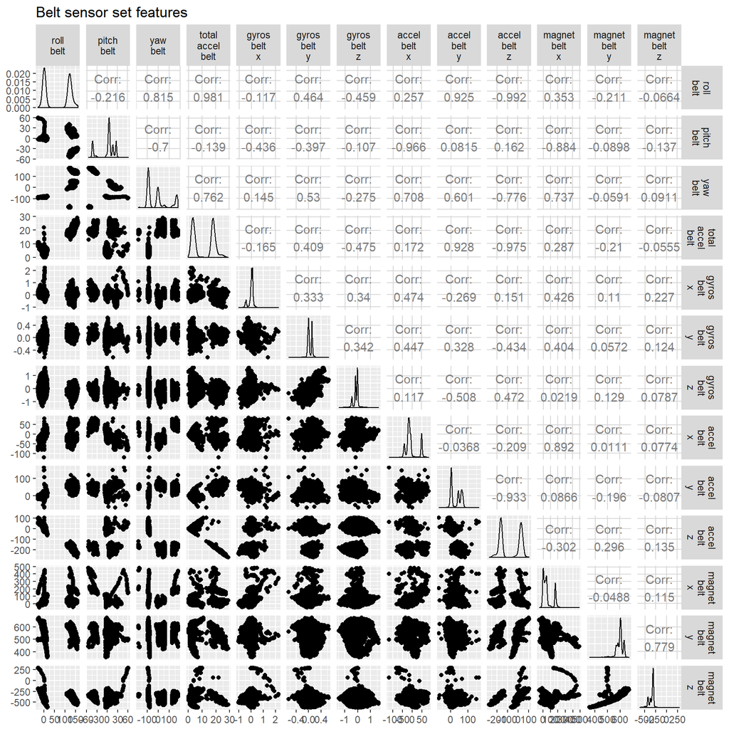

#### Dumbbell sensor set

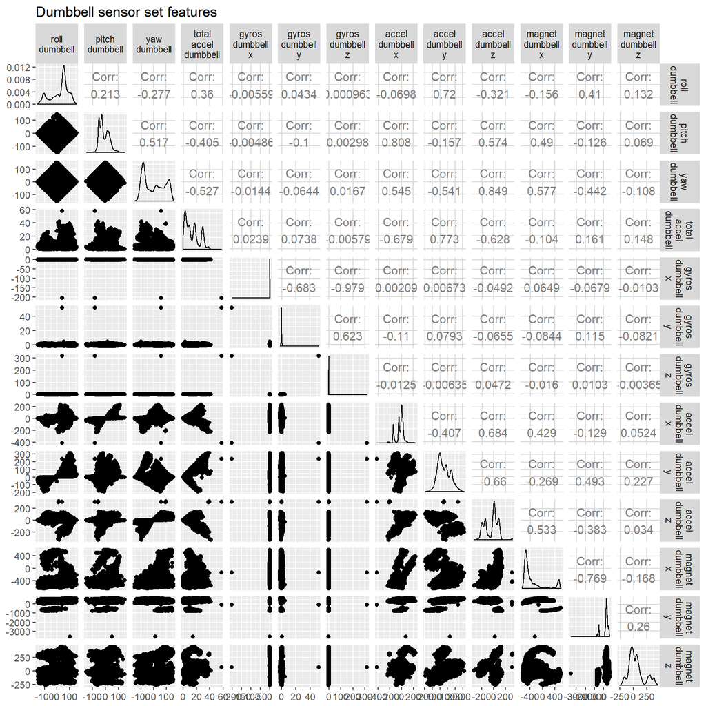

#### Forearm sensor set

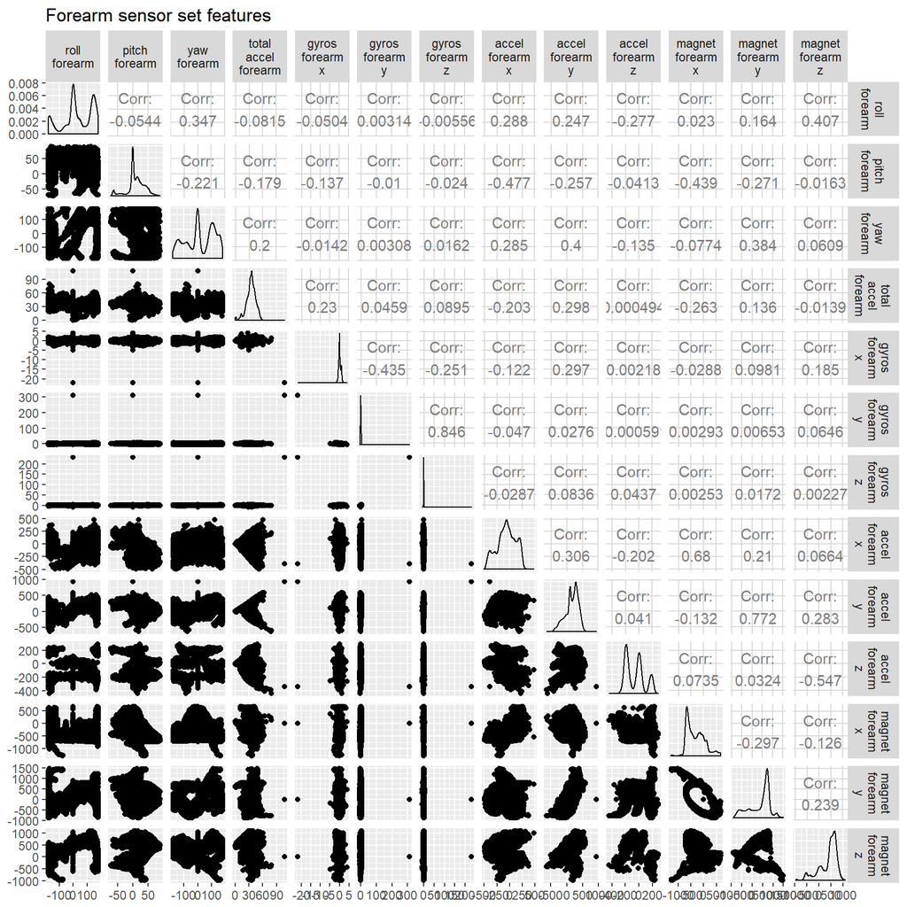

#### Axial signals

##### Arm axial signals

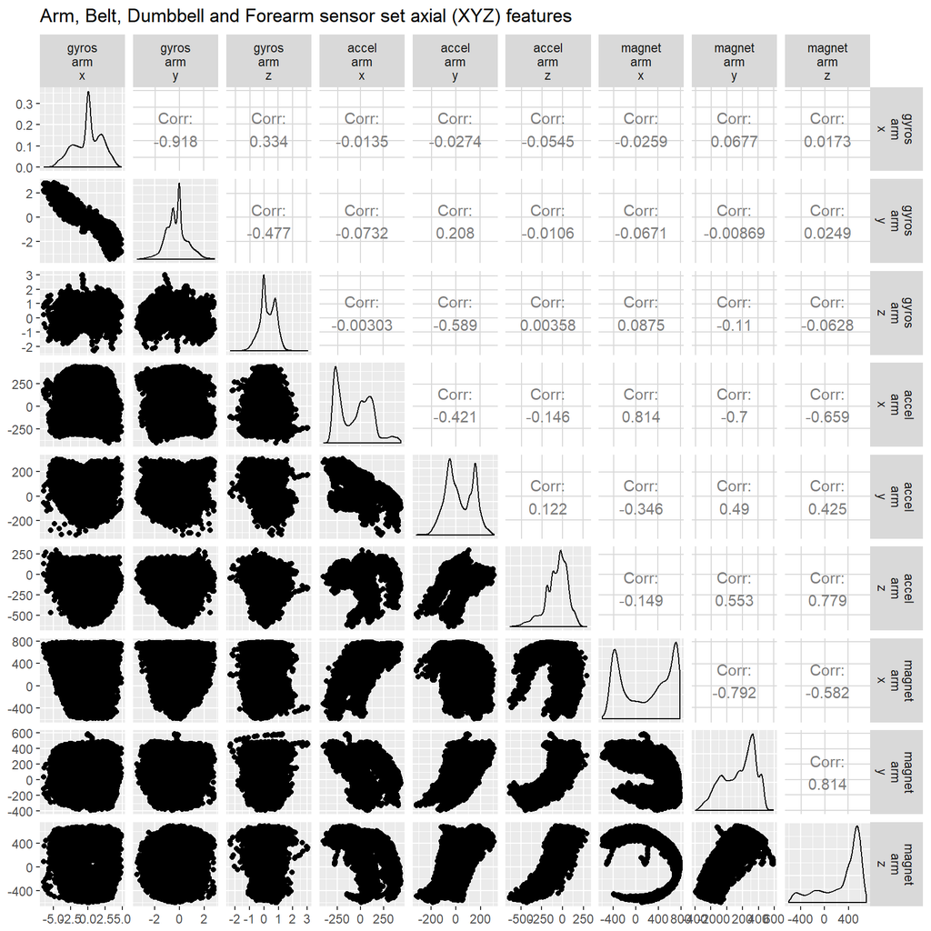

##### Belt axial signals

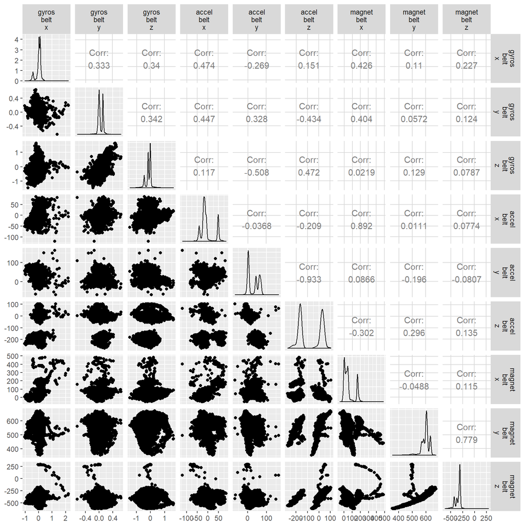

##### Dumbbell axial signals

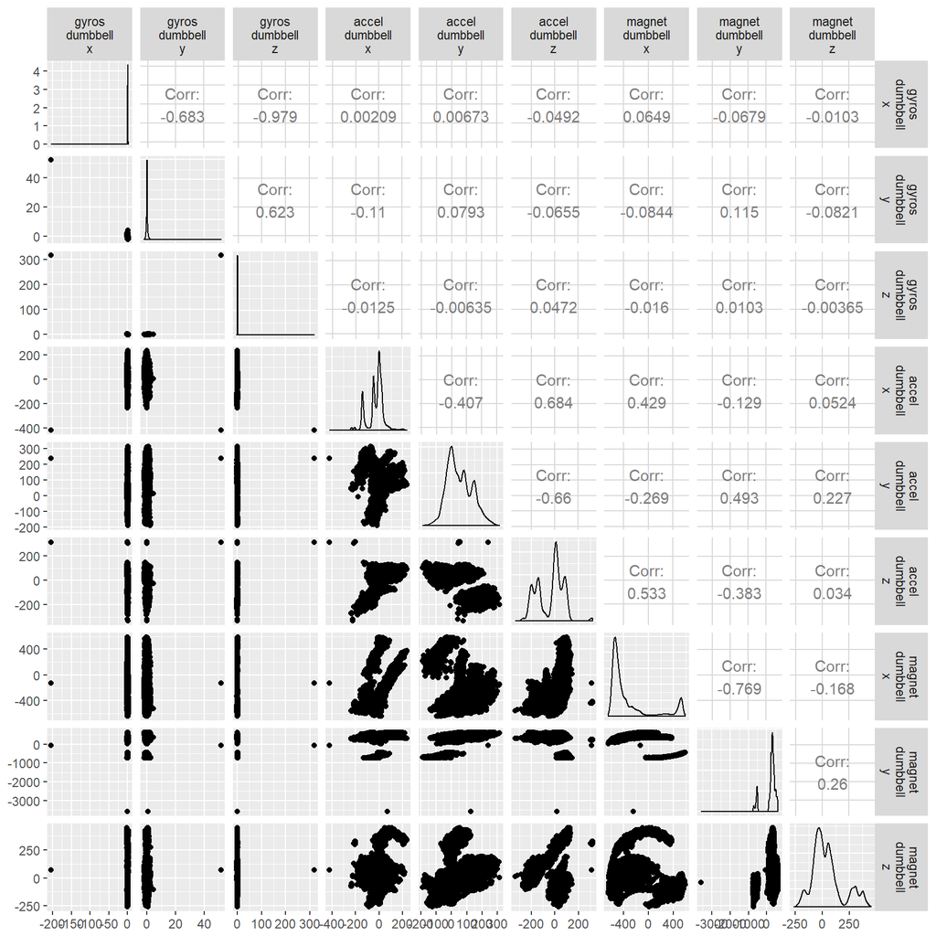

##### Forearm axial signals

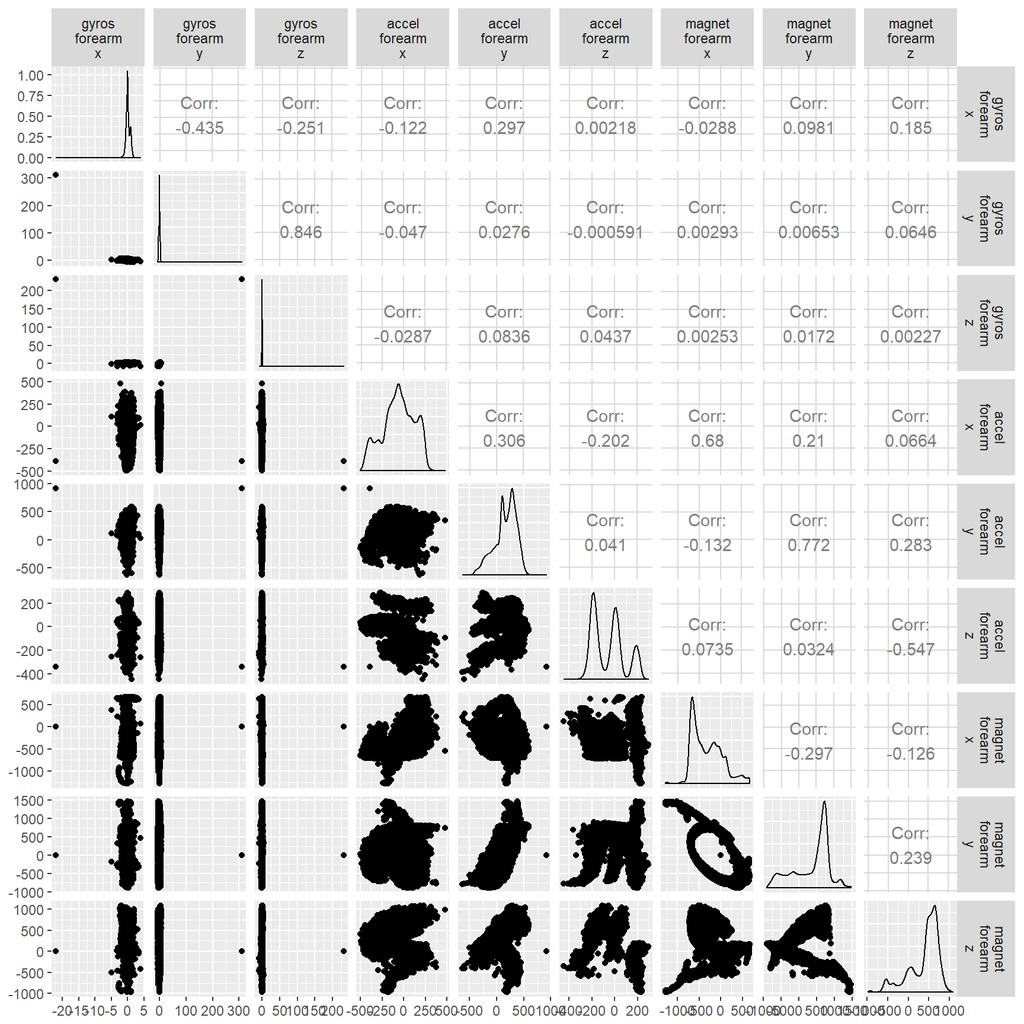